# Tess Newkold

My Introduction!

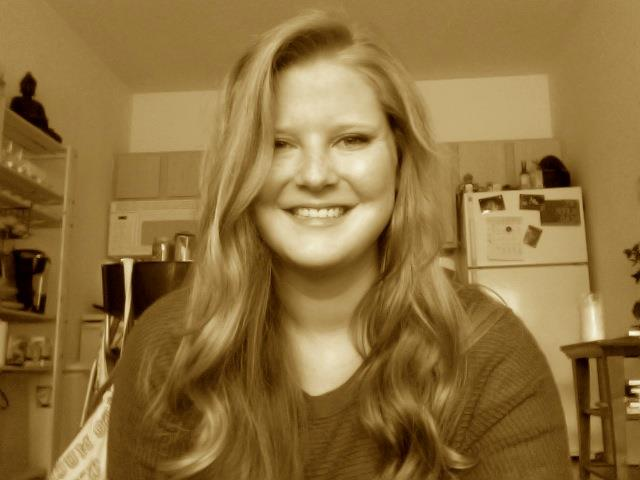

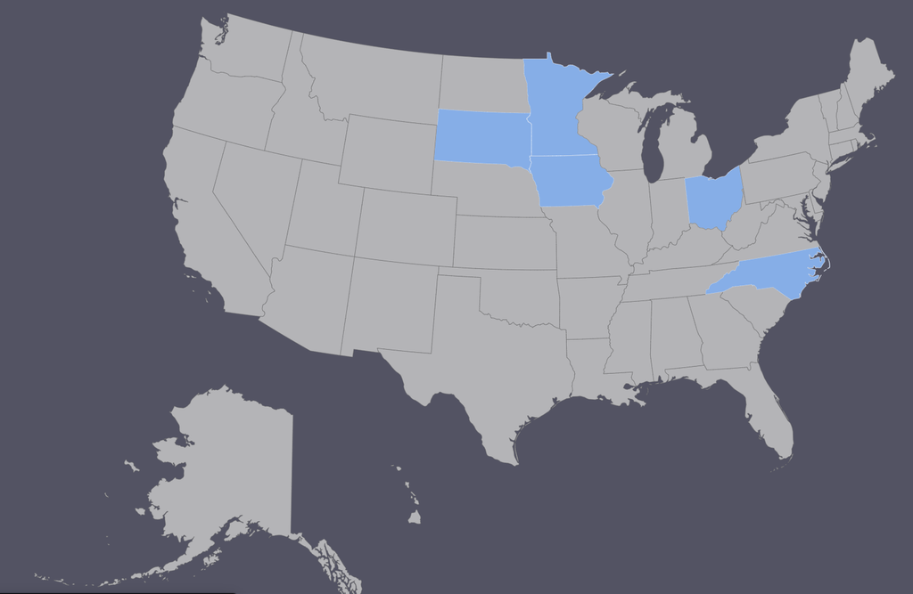

Hello, my name is Tess! I currently live in Dayton, OH. However, I have moved around a lot in my life. I have lived in Iowa, Minnesota, South Dakota, North Carolina, and now Ohio!

### Academic Background

- B.S. in Biology from [The University of North Carolina - Wilmington](https://uncw.edu/) in Wilmington, NC
- *Currently* M.S. in Buisness Analytics from [University of Cincinnati](https://www.uc.edu/) in Cincinnati, OH

### Professional Background

With my previous degree in Biology I originally wanted to enter the Developmental Biology field. I worked at Cincinnati Childrens in the [Fetal Department](https://www.cincinnatichildrens.org/research/divisions/c/fetal-placental-research/research), studing the development of the fetal immune system and their potential ability to receive a stem cell transplant *in utero*. I then became a Lab Manager in the [Experimental Hematology and Cancer Biology Department](https://www.cincinnatichildrens.org/research/divisions/e/ex-hem/research/hematological-malignancy) for Dr. Leighton Grimes. We studied how the biological processes of cell development goes wrong. I became very interested in the data analysis our colaborators were doing! That is why I enrolled in the Business Analytics program at University of Cincinnati.

### Experience with R

- None! …except the R Bootcamp at orientation.

### Experience with Other Coding Languages

- C++